# 4.0_gamma-gamma_coincidence_0

## 4.0 $\gamma - \gamma$ coincidence data analysis

### 目的：

1. gamma-gamma 符合分辨时间，timewalk correction
2. 多探测单元探测器的addback

[figure not shown]

[figure not shown]

- Data
  - eurica.root
  - Branch：

    ```
    - ghit, gid[ghit], ge[ghit], gt[ghit];// sorted by gid value in ascending order
    - ahit, aid[ahit], ae[ahit], at[ahit];//addback
    ```

  - 所有探测器的相对时间延迟已经校正

```python
TCanvas *c1=new TCanvas("c1","c1");
TFile *fin=new TFile("eurica.root");
TTree *tree1=(TTree*) fin->Get("tree");
```

```python
tree1->Scan("gid:int(gid/7):gid%7:ge:gt","","",5,1);
```

```
*    Row   * Instance *       gid * int(gid/7 *     gid%7 *        ge *        gt *
*        1 *        0 *        38 *         5 *         3 * 355.39204 * -17058.86 *
*        1 *        1 *        78 *        11 *         1 * 252.57337 * -52075.91 *
*        2 *        0 *        22 *         3 *         1 * 721.78308 * -23301.26 *
*        2 *        1 *        24 *         3 *         3 * 69.567794 * -23329.60 *
*        2 *        2 *        27 *         3 *         6 * 187.30067 * -23277.87 *
*        2 *        3 *        28 *         4 *         0 * 166.66361 * -17738.86 *
*        2 *        4 *        32 *         4 *         4 * 73.365846 * 4244.7660 *
*        2 *        5 *        37 *         5 *         2 * 856.34057 * -17667.32 *
*        2 *        6 *        41 *         5 *         6 *  121.9316 * -5041.272 *
*        2 *        7 *        44 *         6 *         2 * 257.20985 * -5065.583 *
*        2 *        8 *        79 *        11 *         2 * 679.46405 * -84233.31 *
*        2 *        9 *        80 *        11 *         3 * 595.97674 * -84263.73 *
*        3 *        0 *         4 *         0 *         4 * 345.00679 * -88546.18 *
*        3 *        1 *        17 *         2 *         3 * 94.129311 * -88728.07 *
*        4 *        0 *         5 *         0 *         5 * 287.14200 * -91794.79 *
*        4 *        1 *         8 *         1 *         1 * 302.35514 * -19152.93 *
*        4 *        2 *        69 *         9 *         6 * 37.762305 * -36942.37 *
*        5 *        0 *        45 *         6 *         3 * 232.74277 * -59180.04 *
*        5 *        1 *        75 *        10 *         5 * 334.94150 * -38333.97 *
```

## time walk

- 前沿定时的timewalk：
  - 幅度越小，timewalk越大。幅度大到某一值时timewalk可以忽略。

[figure not shown]

  - CFD在信号幅度较小时也有timewalk
- 中子探测器(plastic)也有类似的特征

### 两个探测器的时间差分布

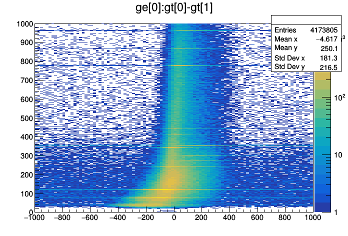

```python
tree->Draw("ge[0]:gt[0]-gt[1]>>(100,-1000,1000,1000,0,1000)","","colz");
c1->SetLogz();
c1->Draw();
```

### 排除参考时间路gt[1]的timewalk

- 选择ge[1]>400的条件，去掉gt[1]的timewalk的影响

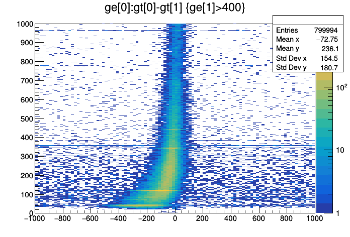

```python
tree->Draw("ge[0]:gt[0]-gt[1]>>(100,-1000,1000,1000,0,1000)","ge[1]>400","colz");
c1->SetLogz();
c1->Draw();
```

### timewalk correction

- 消除定时点的幅度依赖
- walk 修正，通过拟合的得到a值，调整b，将时间差中心值调整到0. $$ t \to t+\frac{a}{\sqrt{e}}+b $$

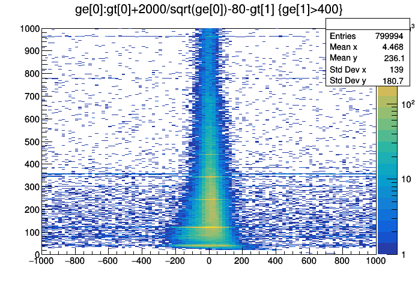

```python
tree->Draw("ge[0]:gt[0]+2000/sqrt(ge[0])-80-gt[1]>>(100,-1000,1000,1000,0,1000)","ge[1]>400","colz");
c1->SetLogz();
c1->Draw();
```

### 对所有时间路做timewalk修正

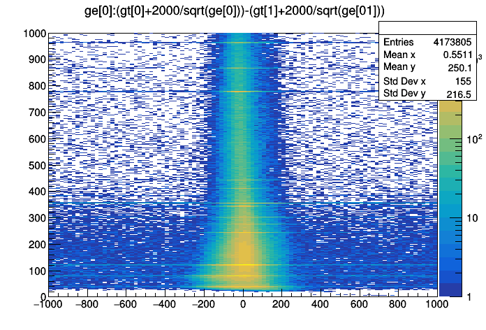

```python
tree->Draw("ge[0]:(gt[0]+2000/sqrt(ge[0]))-(gt[1]+2000/sqrt(ge[01]))>>(100,-1000,1000,1000,0,1000)","","colz");
c1->SetLogz();
c1->Draw();
```

### 符合时间窗

- 符合时间窗的宽度一般取$3\sigma=200$ns
- 如果统计足够可以去更窄的符合时间窗
  - 注意窄的符合时间窗的选取可能会丢掉一部分低能gamma的符合事件。

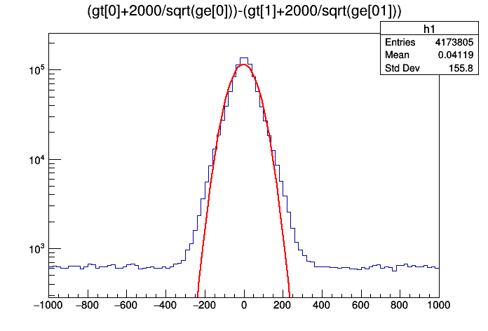

```
 FCN=84827.2 FROM MIGRAD    STATUS=CONVERGED     113 CALLS         114 TOTAL
                     EDM=1.08239e-08    STRATEGY= 1      ERROR MATRIX ACCURATE
  EXT PARAMETER                                   STEP         FIRST
  NO.   NAME      VALUE            ERROR          SIZE      DERIVATIVE
   1  Constant     1.16216e+05   1.70516e+02   1.66079e+01  -8.17398e-07
   2  Mean        -1.53239e-01   6.83091e-02   9.71441e-03  -3.03178e-04
   3  Sigma        6.79639e+01   7.26221e-02   2.22266e-05  -9.27476e-01
```

```python
tree->Draw("(gt[0]+2000/sqrt(ge[0]))-(gt[1]+2000/sqrt(ge[01]))>>h1(100,-1000,1000)","","colz");
h1->Fit("gaus");
gPad->SetLogy();
c1->Draw();
```

## 探测器单元间符合关系

- 二维图中计数最多的方块显示gid之间的关联关系
- 0-7中 (0,1),(1,2)(2,3)(3,4)(4,5)(0,5);(0-5,6)之间有很强的关联
  - 与探测器中探测单元的相邻关系一致

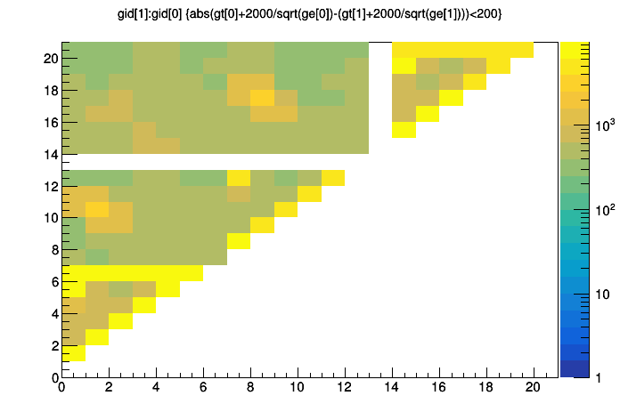

```python
gPad->SetLogy(0);
TCut gtcoin="abs(gt[0]+2000/sqrt(ge[0])-(gt[1]+2000/sqrt(ge[1])))<200";//coincidence time window
tree->Draw("gid[1]:gid[0]>>(21,0,21,21,0,21)",gtcoin,"colz");
gStyle->SetOptStat(0);//off statistics box, https://root.cern.ch/doc/master/classTPaveStats.html
c1->Draw();
```

### 同一探测器的相邻探测单元之间能量关联

- 可以看到相邻探测单元的大部分关联事件是由一个$\gamma-$射线在相邻单元间的康普顿散射引起的。

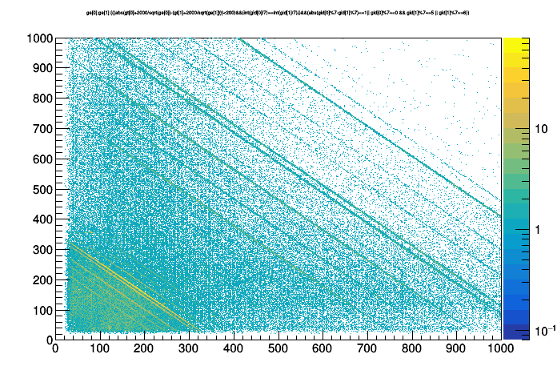

```python
TCut gdet="int(gid[0]/7)==int(gid[1]/7)";//same detector
TCut gidadj="abs(gid[0]%7-gid[1]%7)==1|| gid[0]%7==0 && gid[1]%7==5 || gid[1]%7==6";//adjacent crystals
tree->Draw("ge[0]:ge[1]>>(1000,0,1000,1000,0,1000)",gtcoin&&gdet&&gidadj,"colz");
c1->Draw();
```

#### 相邻探测单元关联-时间差不在符合时间窗内

- 显示为非物理关联事件，偶然符合
  - 偶然符合特征：
  - 当在x探测单元有强度较强的能量为$E_x$的$\gamma-$射线时，会形成$y=E_x$的连续直线，即$E_x$与y探测器任意能量都有关联。
  - 上述x，y上的直线之间的交叉点的计数为x，y方向直线平均计数之和。

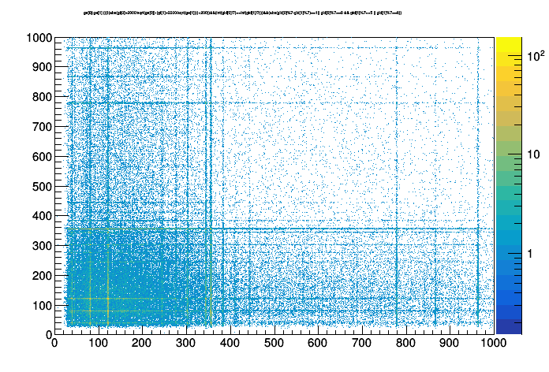

```python
TCut gdet="int(gid[0]/7)==int(gid[1]/7)";//same detector
TCut gidadj="abs(gid[0]%7-gid[1]%7)==1|| gid[0]%7==0 && gid[1]%7==5 || gid[1]%7==6";//adjacent crystals
tree->Draw("ge[0]:ge[1]>>(1000,0,1000,1000,0,1000)",!gtcoin&&gdet&&gidadj,"colz");
c1->Draw();
```

### ge[0],ge[1]的能谱 - 图(a)

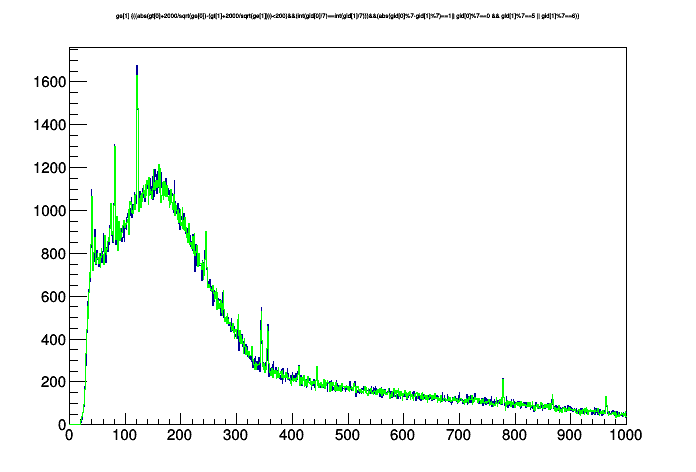

```python
tree->Draw("ge[0]>>h1(1000,0,1000)",gtcoin&&gdet&&gidadj,"colz");
TH1F *h1=(TH1F*)gROOT->FindObject("h1");
h1->SetLineColor(kGreen);
tree->Draw("ge[1]>>h2(1000,0,1000)",gtcoin&&gdet&&gidadj,"colz");
h1->Draw("same");
c1->Draw();
```

# addback

- 多单元探测器中相邻单元之间的能量共享(compton)
- 为了减少康普顿平台，相邻单元之间的能量应该相加

### 相邻探测器的addback

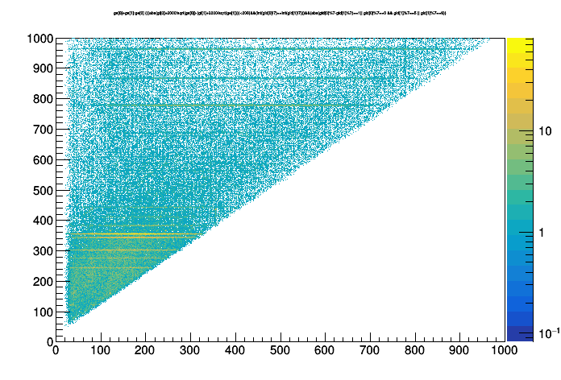

```python
tree->Draw("ge[0]+ge[1]:ge[0]>>(1000,0,1000,1000,0,1000)",gtcoin&&gdet&&gidadj,"colz");
c1->Draw();
```

### addback后的ge[0]+ge[1]的能谱- 图(b)

- 对高能$\gamma-$射线有显著的增强效果

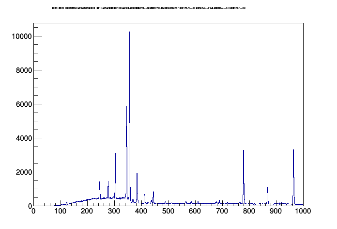

```python
tree->Draw("ge[0]+ge[1]>>(1000,0,1000)",gtcoin&&gdet&&gidadj,"colz");
c1->Draw();
```

### 同一探测器的不相邻探测单元之间能量关联

- 不相邻相邻探测单元的关联事件是由一部分康普顿散射以及两个$\gamma-$射线入射引起的。
- 真正的$(E_x，E_y)$的符合特征是，$(E_x,E_y)$上有交叉点，且该点计数相比于x方向和y方向连续直线计数之和更高。
  - 从$(E_x,E_y)$点开始沿x方向和y方向一直延伸到低能位置。(康普顿散射导致)
- 每个交叉点是否为真正的符合事件，要根据上述原则仔细判断。
  - 除了个别情况外，一般来说 $(E_x = E_y)$ 的点是由偶然符合引起的。

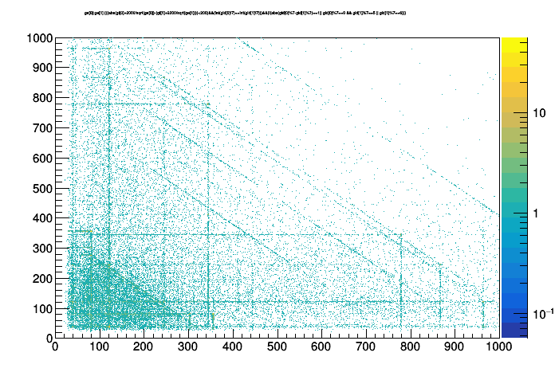

```python
tree->Draw("ge[0]:ge[1]>>(1000,0,1000,1000,0,1000)",gtcoin&&gdet&&!gidadj,"colz");
c1->Draw();
```

### 同一探测器的不相邻探测单元的ge[0],ge[1]- 图(c)

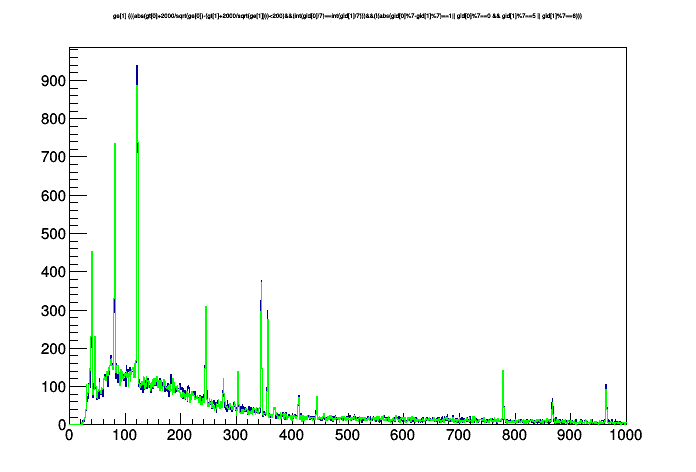

```python
tree->Draw("ge[0]>>h1(1000,0,1000)",gtcoin&&gdet&&!gidadj,"colz");
TH1F *h1=(TH1F*)gROOT->FindObject("h1");
h1->SetLineColor(kGreen);
tree->Draw("ge[1]>>h2(1000,0,1000)",gtcoin&&gdet&&!gidadj,"colz");
h1->Draw("same");
c1->Draw();
```

### 不同探测器的探测单元之间能量关联

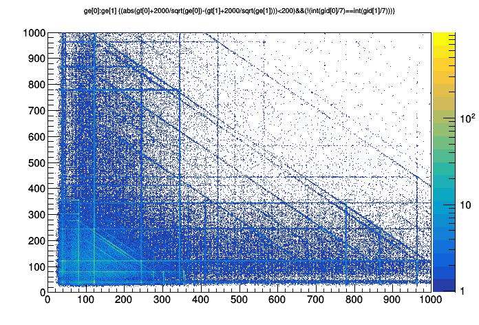

```python
tree->Draw("ge[0]:ge[1]>>(1000,0,1000,1000,0,1000)",gtcoin&&!gdet,"colz");
c1->Draw();
```

### Addback之后的不同探测器的能量关联

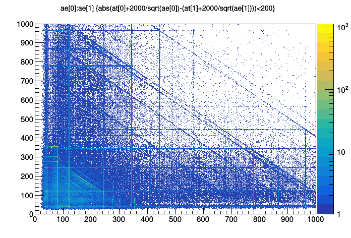

```python
TCut atcoin="abs(at[0]+2000/sqrt(ae[0])-(at[1]+2000/sqrt(ae[1])))<200";//coincidence time window
tree->Draw("ae[0]:ae[1]>>(1000,0,1000,1000,0,1000)",atcoin,"colz");
c1->Draw();
```

### addback 前后能谱对比

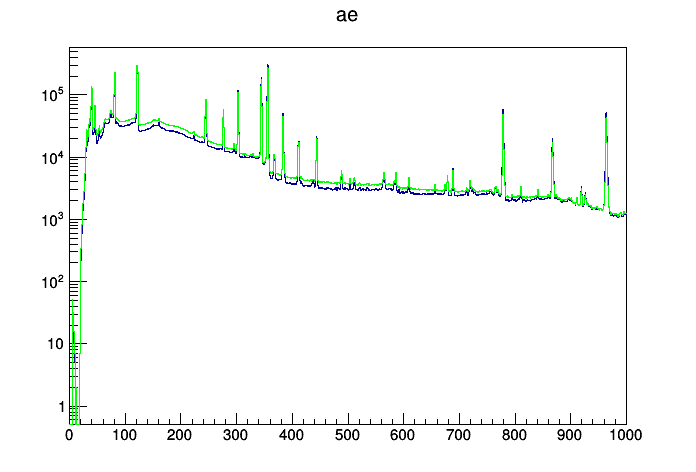

```python
tree->Draw("ge>>h1(1000,0,1000)","","colz");
TH1F *h1=(TH1F*)gROOT->FindObject("h1");
h1->SetLineColor(kGreen);
tree->Draw("ae>>h2(1000,0,1000)","","colz");
h1->Draw("same");
c1->SetLogy();
c1->Draw();
```

## Addback 注意事项

- 除了一个探测器内相邻单元之外，几何上相邻的不同探测器的探测单元之间也可以做addback。
- 当源与探测器之间距离较远时，不同gamma射线进入相邻探测单元的几率很小，此时相邻探测器的关联主要是compton散射，
  - 此时进行addback可以提高探测器的peak-compton ratio
  - 如果不同探测器的探测单元之间摆放的很近时，也可以进行addback
- 当源与探测器之间距离很近时，不同gamma射线进入相邻探测单元的几率大大增加，此时addback会将两个gamma射线能量相加，造成假的gamma峰。
  - 比如$E_{\gamma 1}$与$E_{\gamma 2}$入射到相邻探测单元，addback会消除$E_{\gamma 1}$与$E_{\gamma 2}$位置的峰，造成假的加合峰$E_{\gamma}=E_{\gamma 1}+E_{\gamma 2}$
- 基于上述原因，一般情况下应该同时保留各个探测单元的事件以及addback的事件，分析时注意对比addback前后的数据，避免addback的副作用。

### Addback 示例代码，以clover探测器为例

[figure not shown]

[output not shown]

- gamma数据由XIA数字化获取系统获取，采集卡100MHz，14-bit
- 数据结构：每个事件由(gid, gt, ge) 组成，按照事件发生的顺序(gt递增顺序)进行记录, gid/4代表探测器编号，gid%4代表探测单元。 (不同探测器之间由电子学导致的相对时间差已修正。)
  - 如：(10, 22000, 237), (15, 22010, 568), (11, 22110, 784), (20,32000,500)...

- 如果在一个探测器内有多个单元有信号，按上述规则进行addback。
- aflag: single:10-13, double: 21,22,23(0+3,1+2),24, triple: 33,34,35,36...

```
void Reset(Long64_t &gt0, Long64_t gt,
       int nDet, Int_t *amul,Int_t *aflag, Double_t *ae, Long64_t *at)
{
  for(int i=0; i<nDet; i++) {
    ae[i] = 0;
    at[i] = -1;
    aflag[i] = 0;
    amul[i] = 0;
  }
  gt0 = gt;
}

void gamma()
{
  //input
  TFile* f=new TFile("gamma.root");
  TTree* tree=(TTree*)f->Get("t");

  Int_t gid;
  Double_t ge;
  Long64_t gt;
  tree->SetBranchAddress("flagcrystal", &gid);
  tree->SetBranchAddress("ecrystal", &ge);
  tree->SetBranchAddress("tcrystal", &gt);

  //output
  const Int_t nDet = 20;//number of clover detectors.
  Int_t ahit;
  Int_t adet[nDet], aflag[nDet];
  Double_t ae[nDet];
  Long64_t at[nDet];
  TFile *fout = new TFile("addback.root","recreate");
  TTree* tout = new TTree("tree","event");
  tout->Branch("ahit", &ahit, "ahit/I");
  tout->Branch("adet", &adet, "adet[ahit]/I");
  tout->Branch("ae", &ae, "ae[ahit]/D");
  tout->Branch("at", &at, "at[ahit]/L");
  tout->Branch("aflag", &aflag, "aflag[ahit]/I");

  Double_t ae1[nDet];
  Long64_t at1[nDet];
  Int_t aflag1[nDet];
  Int_t amul1[nDet];

  //event loop
  Long64_t gt0;
  Long64_t nentries = tree->GetEntriesFast();
  for(Long64_t jentry = 0; jentry < nentries; jentry++) {
    tree->GetEntry(jentry);
    if(jentry == 0) {
      Reset(gt0, gt, nDet, amul1, aflag1, ae1, at1);
    }
    else if(gt-gt0 > 1000) {
      ahit = 0;
      for(int i=0; i <nDet; i++) {
        if(ae1[i] < 10) continue;
        adet[ahit] = i;
        ae[ahit] = ae1[i];
        at[ahit] = at1[i];
        aflag[ahit] = aflag1[i] + amul1[i] * 10;
        if(aflag[ahit] == 23) continue; //reject 0-3,1-2 in double-hit
        if(aflag[ahit] >29) continue; //reject triple-hit，quadruple-hit
        ahit ++;
       }
      tout->Fill();
      Reset(gt0, gt, nDet, amul1, aflag1, ae1, at1);
    }
    int idet = gid / 4;
    int id = gid % 4;
    ae1[idet] += ge;
    if(at1[idet]<0) at1[idet] = gt;
    amul1[idet] ++;
    aflag1[idet] += id;

    if((jentry) % Long64_t(1e5) == 0) {
      printf("Process %.2f %%, %5d k / %5d k \r",Double_t(jentry)/nentries*100.,
         int(jentry/1000), int(nentries/1000));
      fflush(stdout);
    }
  }
  cout<<endl;
  tout->Write();
  fout->Close();
}
```